# limit theorems - Google Search

[interactive chart not shown]

[figure not shown]

[figure not shown]

## Search Results

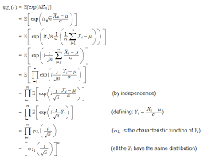

599 × 464 - statlect.com

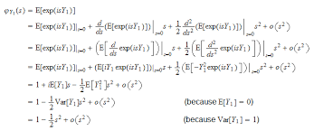

635 × 266 - statlect.com

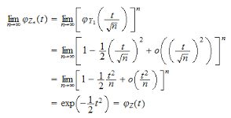

368 × 188 - statlect.com

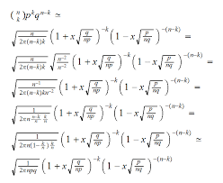

669 × 549 - academic.uprm.edu

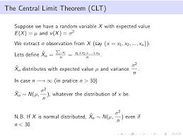

638 × 479 - slideshare.net

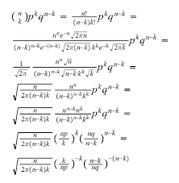

491 × 501 - academic.uprm.edu

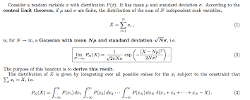

881 × 354 - math.stackexchange.com

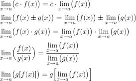

342 × 205 - math.feld.cvut.cz

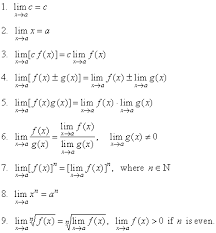

355 × 382 - nabla.hr

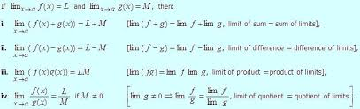

653 × 199 - phengkimving.com

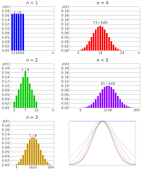

2000 × 2398 - en.wikipedia.org

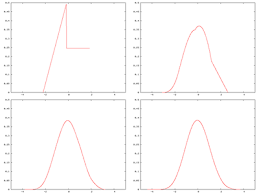

400 × 300 - en.wikipedia.org

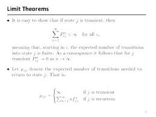

358 × 269 - yumpu.com

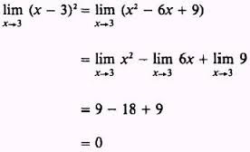

345 × 210 - tpub.com

[figure not shown]

738 × 1119 - link.springer.com

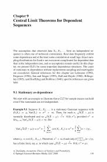

738 × 1114 - link.springer.com

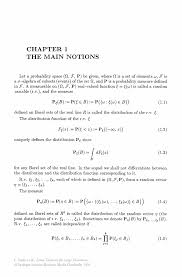

738 × 1120 - link.springer.com

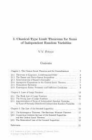

738 × 1119 - link.springer.com

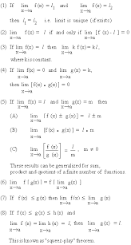

381 × 713 - pinkmonkey.com

[figure not shown]

555 × 260 - ocw.usu.edu

[figure not shown]

341 × 121 - statlect.com

[figure not shown]

929 × 1050 - ww2.amstat.org

[figure not shown]

320 × 240 - mathvids.com

[figure not shown]

358 × 507 - yumpu.com

[figure not shown]

358 × 507 - yumpu.com

[figure not shown]

357 × 462 - yumpu.com

[figure not shown]

738 × 1172 - link.springer.com

[figure not shown]

500 × 402 - en.wikipedia.org

[figure not shown]

358 × 269 - yumpu.com

[figure not shown]

357 × 462 - yumpu.com

[figure not shown]

1024 × 768 - en.wikipedia.org

[figure not shown]

358 × 543 - yumpu.com

[figure not shown]

357 × 462 - yumpu.com

[figure not shown]

358 × 507 - yumpu.com

[figure not shown]

357 × 462 - yumpu.com

[figure not shown]

738 × 1120 - link.springer.com

[figure not shown]

4096 × 2304 - youtube.com

[figure not shown]

357 × 462 - yumpu.com

[figure not shown]

358 × 507 - yumpu.com

[figure not shown]

358 × 507 - yumpu.com

[figure not shown]

358 × 507 - yumpu.com

[figure not shown]

357 × 462 - yumpu.com

[figure not shown]

358 × 515 - yumpu.com

[figure not shown]

1280 × 720 - youtube.com

[figure not shown]

738 × 1079 - link.springer.com

[figure not shown]

357 × 462 - yumpu.com

[figure not shown]

357 × 462 - yumpu.com

[figure not shown]

358 × 507 - yumpu.com

[figure not shown]

728 × 546 - slideshare.net

[figure not shown]

358 × 507 - yumpu.com

[figure not shown]

747 × 389 - encyclopedia2.thefreedictionary.com

[figure not shown]

655 × 223 - stat.wmich.edu

[figure not shown]

638 × 903 - slideshare.net

[figure not shown]

738 × 1054 - link.springer.com

[figure not shown]

690 × 297 - academic.uprm.edu

[figure not shown]

738 × 1079 - link.springer.com

[figure not shown]

738 × 1119 - link.springer.com

[figure not shown]

738 × 1119 - link.springer.com

[figure not shown]

3024 × 2268 - stats.stackexchange.com

[figure not shown]

1280 × 720 - youtube.com

[figure not shown]

728 × 546 - slideshare.net

[figure not shown]

738 × 1119 - link.springer.com

[figure not shown]

738 × 1114 - link.springer.com

[figure not shown]

738 × 1119 - link.springer.com

[figure not shown]

638 × 903 - slideshare.net

[figure not shown]

738 × 1119 - link.springer.com

[figure not shown]

738 × 1114 - link.springer.com

[figure not shown]

738 × 1119 - link.springer.com

[figure not shown]

738 × 1114 - link.springer.com

[figure not shown]

738 × 1120 - link.springer.com

[figure not shown]

738 × 1119 - link.springer.com

[figure not shown]

738 × 1119 - link.springer.com

[figure not shown]

900 × 306 - stats.stackexchange.com

[figure not shown]

638 × 903 - slideshare.net

[figure not shown]

480 × 360 - youtube.com

[figure not shown]

638 × 903 - slideshare.net

[figure not shown]

638 × 903 - slideshare.net

[figure not shown]

638 × 903 - slideshare.net

[figure not shown]

385 × 328 - scielo.br

[figure not shown]

320 × 240 - slideserve.com

[figure not shown]

480 × 360 - youtube.com

[figure not shown]

728 × 546 - slideshare.net

[figure not shown]

960 × 720 - slideplayer.com

[figure not shown]

357 × 276 - epixanalytics.com

[figure not shown]

1800 × 1080 - youtube.com

[figure not shown]

568 × 259 - home.ubalt.edu

[figure not shown]

320 × 266 - cal45sw08.blogspot.com

[figure not shown]

596 × 775 - people.stat.sfu.ca

[figure not shown]

960 × 720 - slideplayer.com

[figure not shown]

434 × 164 - tutorial.math.lamar.edu

[figure not shown]

638 × 903 - slideshare.net

[figure not shown]

728 × 546 - slideshare.net

[figure not shown]

1280 × 720 - cyberspaceandtime.com

[figure not shown]

638 × 903 - slideshare.net

[figure not shown]

300 × 225 - en.wikipedia.org

[figure not shown]

607 × 335 - academic.uprm.edu

[figure not shown]

485 × 279 - ocw.usu.edu

[figure not shown]

680 × 421 - academic.uprm.edu

[figure not shown]

738 × 1114 - link.springer.com

[interactive chart not shown]